# Wikipedia text-mining: 20th-century women scientists

Michael Malis, Markiel Kaykov

## Background

This project walks through an end-to-end text-mining workflow centred on Wikipedia biographies of notable 20ᵗʰ-century female scientists. Starting from the master list  
https://en.wikipedia.org/wiki/List_of_female_scientists_in_the_20th_century,  
we scrape every name, follow each link to harvest and clean the full biography, and assemble a unified corpus for analysis.

With this corpus we:

- build word-frequency tables, stop-word-filtered word clouds, and single-/bi-letter frequency matrices;
- assess how well individual biographies estimate the global frequency of the letter **a**;
- create empirical letter and bigram models to simulate random words and check them against an English dictionary;
- run Monte-Carlo “typing-monkey” experiments to quantify rare events—repeating a word, assembling three Curie family names, and randomly producing the name **“Rosalind Franklin.”**

## Libraries used in this project

- **tidyverse** – data wrangling (`dplyr`, `purrr`), string handling (`stringr`), and general utilities
- **rvest** – scraping HTML content from Wikipedia
- **ggplot2** – creating all visualisations
- Base R setting `options(scipen = 999)` to suppress scientific-notation output

### Extract scientist names from Wikipedia

We scrape the 20ᵗʰ-century female-scientist list, keep only entries with a birth or death year, and build a unique vector of names.

We scraped the list of notable female scientists from Wikipedia using `rvest`, filtering only entries that included a birth or death year using a regular expression. This ensures that only real individuals are included. From the filtered list items, we extracted names by trimming the text before the first parenthesis.

```r
page_url  <- "https://en.wikipedia.org/wiki/List_of_female_scientists_in_the_20th_century"
year_pat <- "\\((born\\s+\\d{4}|died\\s+\\d{4}|\\d{4}\\s*\\u2013\\s*\\d{4})\\)"   # pattern for years

get_li_good <- function(pageURL) {      # return <li> nodes that hold a year pattern
  page     <- read_html(pageURL)
  li_nodes <- html_nodes(page, "ul > li")
  li_nodes[str_detect(html_text2(li_nodes), year_pat)]
}

get_names <- function(li_vec) {     # pull unique names - text before first '('
  li_vec %>%
    html_text2() %>%
    str_extract("^[^(]+") %>%
    str_trim() %>%
    unique()
}

li_good      <- get_li_good(page_url)    # shared base for both outputs
names_vector <- get_names(li_good)  # final list of names

length(names_vector)
```

```
## [1] 546
```

```r
head(names_vector, 10)
```

```
##  [1] "Heloísa Alberto Torres"   "Katharine Bartlett"
##  [3] "Ruth Benedict"            "Anna Bērzkalne"
##  [5] "Alicia Dussán de Reichel" "Dina Dahbany-Miraglia"
##  [7] "Bertha P. Dutton"         "Phebe Fjellström"
##  [9] "Helen Groger-Wurm"        "Zora Neale Hurston"
```

```r
cat("The final result is a unique vector of ", length(names_vector),"names.")
```

```
## The final result is a unique vector of  546 names.
```

The final result is a unique vector of 546 names.

### Build Wikipedia URLs for each scientist

For every name we capture the corresponding internal link, clean it, and create a full Wikipedia URL. *Example:* **Katharine Bartlett** → `https://en.wikipedia.org/wiki/Katharine_Bartlett`.

```r
get_urls <- function(li_vec) {      # pull unique internal wiki links as full urls
  li_vec %>%
    html_element("a") %>%
    html_attr("href") %>%
    str_subset("^/wiki/") %>%
    str_subset(":", negate = TRUE) %>%
    unique() %>%
    paste0("https://en.wikipedia.org", .)
}

names_urls   <- get_urls(li_good)   # matching wiki URLs


head(names_urls, 10)
```

```
##  [1] "https://en.wikipedia.org/wiki/Helo%C3%ADsa_Alberto_Torres"
##  [2] "https://en.wikipedia.org/wiki/Katharine_Bartlett"
##  [3] "https://en.wikipedia.org/wiki/Ruth_Benedict"
##  [4] "https://en.wikipedia.org/wiki/Anna_B%C4%93rzkalne"
##  [5] "https://en.wikipedia.org/wiki/Alicia_Duss%C3%A1n_de_Reichel"
##  [6] "https://en.wikipedia.org/wiki/Dina_Dahbany-Miraglia"
##  [7] "https://en.wikipedia.org/wiki/Bertha_P._Dutton"
##  [8] "https://en.wikipedia.org/wiki/Phebe_Fjellstr%C3%B6m"
##  [9] "https://en.wikipedia.org/wiki/Helen_Groger-Wurm"
## [10] "https://en.wikipedia.org/wiki/Zora_Neale_Hurston"
```

```r
cat("A total of", length(names_urls), "URLs were extracted out of", length(names_vector), "names.\n")
```

```
## A total of 546 URLs were extracted out of 546 names.
```

Each scientist’s name was converted into a Wikipedia-style URL by extracting internal link references from the corresponding list items. These relative paths were filtered to exclude non-article namespaces and then appended to the main Wikipedia domain to form full URLs.

A total of 546 URLs were successfully extracted out of 546 names, achieving a perfect match and exceeding the required threshold of 400. This indicates that the link extraction process was highly accurate and reliable.

### Parse biography text from each page

For every scientist, download the page, keep only the lines between “From Wikipedia…” and “References”, and strip citation markers.  
Use **Katharine Bartlett**’s page to confirm the parser returns her biography correctly.

To retrieve the biographical text for each scientist, we constructed a function `wiki_text_parser` relies on two helper functions: `name_to_url`, which maps a scientist’s name to their corresponding Wikipedia URL, and `parse_bio_page`, which extracts and cleans the biographical content from the HTML page. Together, these components allow for accurate retrieval of structured text from Wikipedia entries.

```r
# helper func, map scientist name to full wiki URL
name_to_url <- function(name) {
  idx <- match(name, names_vector)
  if (is.na(idx)) stop("Name not found in names_vector") # error msg
  names_urls[idx]
}

# pull the main <p> (tag - HTML paragraph element) blocks before References/Notes
parse_bio_page <- function(page) {
  body <- page %>%                          # first <div> under #mw-content-text
    html_element("#mw-content-text") %>%
    html_element("div")

  if (is.null(body)) return("")

  kids <- body %>% html_children()

  start_ind <- which(
    str_detect(
      html_text2(kids),
      regex("From Wikipedia, the free encyclopedia", ignore_case = TRUE)
    )
  )
  if (length(start_ind) == 0) start_ind <- 1
  start_ind <- start_ind[1] + 1                     # move to the node after "From Wikipedia..." banner

  stop_ind <- which(
    html_name(kids) == "h2" &                 #<h2> - HTML tag for second level heading
      str_detect(
        html_text2(kids),
        regex("(References|Notes)", ignore_case = TRUE)
      )
  )
  if (length(stop_ind) == 0) stop_ind <- length(kids) # if no References/Notes header, use last child
  stop_ind <- stop_ind[1] - 1 # o.w. end one node before that header

  if (start_ind > stop_ind) return("")              # nothing to extract

  kids[start_ind:stop_ind] %>%
    keep(~ html_name(.x) == "p") %>%        #keep only <p> paragraph
    html_text2() %>%
    str_remove_all("\\s*\\[\\d+\\]") %>%    #remove [1], [23], ... and space
    paste(collapse = "\n\n")                #join all paragraph into one, inserting a blank line between
}

wiki_text_parser <- function(target) {
  page <- read_html(name_to_url(target))    # get URL by name, read the page
  parse_bio_page(page)                      # extract bio
}

# example
bio_text <- wiki_text_parser("Katharine Bartlett")
cat(bio_text)
```

```
## Katharine Bartlett (1907–2001) was an American physical anthropologist who worked from 1930 to 1952 as the first curator of the Museum of Northern Arizona, cataloging and organizing the museum's holdings, and then as the museum's librarian until 1974 and archivist until 1981. She participated in …
##
## Katharine Bartlett was born on November 30, 1907, in Denver, Colorado, to Louise Erina (née Leedom) and George Frederick Bartlett. Unable to afford her first choice of Smith College, Bartlett obtained her master's degree in physical anthropology from the University of Denver, studying under Etien…
##
## Bartlett organized, cataloged, and preserved the museum's anthropology collection, serving from 1930 to 1952 as the museum curator. In 1931, she and Colton made an archaeological survey of the Navajo Reservation covering 250 miles of the reservation that lies in the Little Colorado River basin. T…
##
## Beginning in 1928, Bartlett published numerous articles on the Native people and cultures of Arizona. Her scientific papers included such topics as ancient mines, artifacts, foods, history, prehistoric tools, as well as crafts of the Hopi, Navajo, and other Arizona tribes. Her article Pueblo Mill…
##
## Bartlett was a charter member of the Arizona Academy of Science and the Arizona Association of University Women. She was a Fellow of the American Association for the Advancement of Science, of the American Anthropological Association, and the first Fellow of the MNA. She was honored by an exhibit…
##
## Bartlett died on May 22, 2001, in Sedona, Arizona, and was posthumously inducted into the Arizona Women's Hall of Fame in 2008.
```

As an example, the biography for “Katharine Bartlett” was successfully extracted and reviewed, confirming that the function correctly isolates the intended textual content.

### Collect all biographies into a single vector

We loop over every URL, safely parse the biography, and store the result; missing pages are skipped with try().

To collect the biographies, we applied the `wiki_text_parser` function to all names in `names_vector`, using `try()` to handle potential errors during parsing. The results were stored in the bio vector.

```r
# vector the same length as names_vector
bio <- rep(NA, length(names_vector))

for (i in seq_along(names_vector)) {
  # try to parse the page; on error keep NA and continue
  txt <- try(wiki_text_parser(names_vector[i]), silent = TRUE)
  if (!inherits(txt, "try-error")) bio[i] <- txt
}

success <- sum(!is.na(bio))
cat("Retrieved", success, "out of", length(bio), "biographies")
```

```
## Retrieved 546 out of 546 biographies
```

The final output, confirms that all biographies were successfully extracted. This demonstrates that the functions for URL matching and text parsing operated correctly across the entire names/URLs, without errors or missing entries.

### Find the astronomer whose son became a statistician

We keyword-search the biographies to locate the correct astronomer and list her *Nature* publications.

To identify the astronomer whose son was a distinguished statistician, we searched the `bio` vector for biographies containing both familial terms such as “son” or “child” and statistical keywords including “statistician”, “statistics”, or “probability theory”. This was combined with an additional filter for “astronomer” or “astronomy” to ensure relevance.

```r
# helper bool func, that checks if a text contains a regex pattern
contains_pattern <- function(txt, pat) {
  res <- str_detect(txt, regex(pat, ignore_case = TRUE))
  ifelse(is.na(res), FALSE, res)   # сhange NA to FALSE
}

# only elements of bio vector that contain son/child and statistician/statistics/probability(or 's)+theory
son_pat <- "(?=.*\\b(?:son|child(?:ren)?)\\b)(?=.*\\b(?:statistician|statistics|probability\\s+theory)\\b)"
named_bio <- set_names(bio, names_vector)

target_name <- names(
  named_bio %>%                       # vector bio with names
    keep(contains_pattern, son_pat) %>%           # keep only bio's that match son pattern
    keep(contains_pattern, "astronom(y|er)"))[1]  # keep only first bio's with contain "astronomy/astronomer"

cat("Astronomer found:", target_name, "\n", "\n")
```

```
## Astronomer found: Ruby Payne-Scott
##
```

```r
# We verified on the wikipedia page html code that every publication appears in
# the References section as a list of <li> elements, so we can filter only those list items.
nature_titles <- target_name %>%
  name_to_url() %>%
  read_html() %>%
  html_elements("li") %>%        # every list item (<li>)
  html_text2() %>%               # plain text
  keep(contains_pattern, "\\bNature\\b") %>%  # keep lines that that match Nature pattern
  str_replace('.*?"([^"]+)".*', '\\1')        # keep only text inside quotes

nature_titles <- nature_titles[!duplicated(tolower(nature_titles))]

cat("Her publications in Nature (duplicates removed case-insensitively) :\n")
```

```
## Her publications in Nature (duplicates removed case-insensitively) :
```

```r
print(nature_titles)
```

```
## [1] "Relative intensity of spectral lines in indium and gallium"
## [2] "Tissue cultures exposed to the influence of a magnetic field"
## [3] "Radio-frequency energy from the sun"
## [4] "Relative times of arrival of bursts of solar noise on different radio frequencies"
```

The result identified Ruby Payne-Scott as the matching scientist. By parsing the reference section of her Wikipedia page, we extracted the titles of her publications in the journal Nature, cleaned them by isolating quoted text, and removed duplicates case-insensitively. The final output included four distinct publication titles, confirming the success of the extraction process.

P.S. Initially, the idea was to extract only the astronomers from the original Wikipedia list and then search within that subset for a scientist whose son was a statistician. However, this approach proved difficult to implement, as it required a deeper understanding of the page’s HTML structure. Since this is not an HTML-oriented task, we opted for a simpler solution based on keyword matching across all biographies. While not necessarily more precise or robust, this method was significantly easier to implement and sufficient for the task at hand.

### Build a word-frequency table and word cloud

After tokenising the combined biographies we drop stop-words, hashtags, and @-handles, count remaining words, and visualise the top 100.

We combined all available biographies into a single lowercase string and tokenized it into individual words. Common English stop words were removed using the `stop_words` list from the `tidytext` package. In addition, we filtered out hashtags (words beginning with “#”), Twitter usernames (words beginning with “@”), and non-alphabetic tokens.

```r
library(tidytext)
library(wordcloud2)
data("stop_words")

all_text_str <- bio[!is.na(bio)] %>%     # drop missing bios
  tolower() %>%                          # lower-case
  paste(collapse = " ")                  # one long string

words_list <- tibble(text = all_text_str) %>%   # tibble arguments: name = value
  unnest_tokens(word, text)                     # split into words, and put them to word-column

clean_words <- words_list %>%
  anti_join(stop_words, by = "word") %>%        # drop any words whose text matches a row in stop_words from tidytext
  filter(!str_starts(word, "#"),                # drop #hashtags
         !str_starts(word, "@"),                # drop @usernames
         str_detect(word, "[a-z]"))             # keep only alphabetic words

top_words_by_freq <- clean_words %>%
  count(word, sort = TRUE) %>%                  # count each word appearance and sort it from the highest frequency
  slice_head(n = 100)                           # top 100 word by appearance

wordcloud2(
  data       = top_words_by_freq,   # words + frequencies
  size       = 0.8,
  color      = "random-light",
  shape      = "circle",            # circle outline
  fontFamily = "Comic Sans MS"     # Comic Sans font, because it's cool!!!
)
```

[interactive chart not shown]

```r
head(top_words_by_freq)
```

```
## # A tibble: 6 × 2
##   word           n
##   <chr>      <int>
## 1 university  2693
## 2 research    2109
## 3 science     1088
## 4 women        999
## 5 school       992
## 6 college      959
```

The remaining words were counted and sorted by frequency. The top 100 most frequent terms were visualized using a circular word cloud. This allows for a quick qualitative view of the most prominent content-related words appearing across all biographies. To visualize the most common words, we used the wordcloud2() function, which displays the top 100 words in a circular layout.

Based on the computed word frequencies, we observe that the most frequent terms across all scientist biographies include “university”, “research”, “science”, “women”, “school”, and “college”. It’s not surprising, becouse these words reflect the dominant themes in the biographies of female scientists.

### Analyse single-letter frequencies

We count every English letter (case-insensitive) across all text, normalise to probabilities, and display a sorted bar-plot.

To analyze the distribution of letters in the biographies, we first combined all the parsed texts into a single lowercase string to ensure case insensitivity. We then split the text into individual characters and filtered out only the 26 standard English letters using a helper function. A frequency table was constructed to count how many times each letter appeared, and these counts were normalized to obtain relative frequencies $p_i = \frac{n_i}{n}$, where $n$ is the total number of letters.

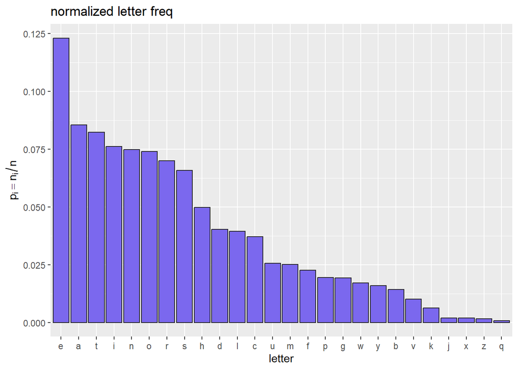

```r
vec_of_latters <- letters

#helper func, return TRUE if x is an English letter
is_letter <- function(x) {
  x %in% vec_of_latters
}

letter_counts <- str_split(all_text_str, pattern = "")[[1]] %>%   # split text for single char and take the first
  keep(is_letter) %>%                 # only letters
  table() %>%                         # make a table, row names =  letters, values = number of they appearance
  as.data.frame() %>%                 # convert todata.frame
  setNames(c("letter", "n"))          # set columns names

letter_counts <- letter_counts %>%                                # take frequency table
  mutate(p = n / sum(n)) %>%                                      # calculate frequencies
  arrange(desc(p))                                                # sort by decreasing p_i

ggplot(letter_counts, aes(x = reorder(letter, -p), y = p)) +      # plot for letters ordered by p_i
  geom_col(fill = "mediumslateblue", color = "gray15") +
  labs(
    title = "normalized letter freq",
    x = "letter",
    y = expression(p[i] == n[i] / n)                              # the proportion/probability of each letter
  )
```

The resulting bar plot shows the sorted frequencies of the letters in descending order. As expected, the most common letters in the dataset are **e**, **a**, **t**, and **i**, which are among the most frequent letters in general English usage. Less frequent letters include **q**, **z**, and **x**, which is also consistent with known language statistics. This analysis confirms that the biographies follow typical English linguistic patterns, dominated by vowels and common consonants.

### Analyse letter-pair (bigram) frequencies

Within each word we tally all 676 possible bigrams into a 26 × 26 matrix, then identify the most- and least-common pairs.

To analyze patterns in letter adjacency, we extracted all consecutive letter pairs (bigrams) from the scientists’ biographies. Only letter pairs within the same word were considered, ignoring whitespace and non-alphabetic characters. The resulting bigrams were counted and stored in a $26 \times 26$ frequency matrix, where each entry corresponds to a pair formed by the first and second letters (rows = first letter).

```r
# generate a vector with every ordered pair of English letters:
# outer(x, y, func) applies func to every pair (x_i, y_j) and returns the
# resulting values in a matrix. func = paste0 builds
# a 26×26 matrix of "aa"…"zz", then as.vector make a vector of length 676
all_possible_bigrams <- as.vector(outer(letters, letters, paste0))

# helper func, return TRUE if word contains at least one letter
# this func will detect "words" that have no alphabetic characters
has_letters <- function(wrd) {
  str_detect(wrd, "[a-z]")
}

# helper func, return all  letter pairs inside one word
word_bigrams <- function(wrd) {

  # split word into a vector of single letters
  chars <- str_split(wrd, "")[[1]]                #[[1]] pulls the first (and only) list element

  if (length(chars) < 2){                         # there is no bigrams in one-letter word
    return(character(0))}                         # return empty character vector

  # maping every char except the last with every char except the first
  bigrams <- paste0(head(chars, -1), tail(chars, -1))
  return(bigrams)
}

# extract bigrams from the aggregated string of bio's
bigrams_vec <- str_split(all_text_str, "\\s+")[[1]] %>%     # split text into words, by one or more spaces
  keep(has_letters) %>%                                     # filter words with alphabetic char
  map(word_bigrams) %>%                                     # get bigrams per word
  unlist() %>%                                              # flatten list to single  vector
  keep(function(x) str_detect(x, "^[a-z]{2}$"))             # keep only pure letter pairs

# count frequencies, include zero counts for missing pairs
# For missing levels the values will be NA, but table() will turn them into 0.
bigram_counts <- table(factor(bigrams_vec, levels = all_possible_bigrams))

# reshape into a 26×26 matrix, rows = first letter
bigram_table <- matrix(
  bigram_counts,
  nrow = 26, ncol = 26,
  dimnames = list(letters, letters)        # label rows and columns with letters a–z
)

# get max and min values
max_count <- max(bigram_counts)
min_count <- min(bigram_counts)

# extract all bigrams with those counts
max_pairs <- names(bigram_counts[bigram_counts == max_count])
min_pairs <- names(bigram_counts[bigram_counts == min_count])

# collapse with quotes and commas
max_str <- paste0('"', max_pairs, '"', collapse = ", ")
min_str <- paste0('"', min_pairs, '"', collapse = ", ")

cat("Most common:", max_str, "with ", max_count," occuracnes", "\n")
```

```
## Most common: "he" with  69281  occuracnes
```

```r
cat("Least common:", min_str, "with ", min_count," occuracnes", "\n")
```

```
## Least common: "jb", "qd", "jf", "qf", "qg", "xg", "qh", "vh", "cj", "pj", "qj", "xj", "zj", "qk", "xk", "jl", "ql", "qm", "vm", "xm", "qn", "qo", "qp", "bq", "fq", "gq", "jq", "lq", "pq", "tq", "vq", "wq", "yq", "zq", "jt", "qt", "vv", "wv", "vw", "fx", "gx", "hx", "jx", "kx", "lx", "mx", "qx", "…
```

```r
library(knitr) #for table visualization
kable(bigram_table)
```

|  | a | b | c | d | e | f | g | h | i | j | k | l | m | n | o | p | q | r | s | t | u | v | w | x | y | z |
| --- | --- | --- | --- | --- | --- | --- | --- | --- | --- | --- | --- | --- | --- | --- | --- | --- | --- | --- | --- | --- | --- | --- | --- | --- | --- | --- |
| a | 141 | 3886 | 7795 | 8077 | 1141 | 2118 | 3417 | 372 | 4325 | 271 | 1376 | 22083 | 7560 | 41595 | 98 | 3850 | 72 | 26835 | 21538 | 31138 | 3254 | 2702 | 1915 | 289 | 2786 | 338 |
| b | 2974 | 254 | 86 | 19 | 10482 | 8 | 9 | 11 | 2600 | 213 | 5 | 3929 | 69 | 21 | 5062 | 9 | 0 | 3170 | 977 | 238 | 2623 | 17 | 15 | 1 | 2851 | 1 |
| c | 14448 | 40 | 1382 | 42 | 11487 | 17 | 140 | 16249 | 9101 | 0 | 1996 | 3615 | 57 | 112 | 15213 | 13 | 79 | 2604 | 1857 | 8520 | 3142 | 4 | 8 | 1 | 623 | 37 |
| d | 3713 | 77 | 120 | 746 | 15782 | 109 | 740 | 133 | 11049 | 51 | 8 | 373 | 349 | 293 | 2897 | 24 | 11 | 1589 | 1700 | 158 | 4251 | 593 | 285 | 6 | 1263 | 6 |
| e | 14041 | 839 | 11070 | 31560 | 6025 | 2121 | 3603 | 466 | 3934 | 98 | 359 | 11566 | 8786 | 28557 | 2929 | 2913 | 638 | 51374 | 22584 | 8564 | 1158 | 4211 | 2348 | 3496 | 2460 | 119 |
| f | 2713 | 16 | 1 | 3 | 5293 | 1935 | 22 | 2 | 5952 | 13 | 3 | 885 | 26 | 15 | 10104 | 6 | 0 | 5383 | 78 | 2054 | 1393 | 1 | 4 | 0 | 184 | 6 |
| g | 3401 | 36 | 5 | 83 | 8481 | 19 | 362 | 3300 | 4431 | 1 | 70 | 1004 | 120 | 1367 | 1726 | 11 | 0 | 5017 | 791 | 307 | 1777 | 2 | 35 | 0 | 2377 | 3 |
| h | 12472 | 73 | 57 | 329 | 69281 | 7 | 9 | 8 | 10869 | 6 | 29 | 306 | 318 | 1233 | 9198 | 14 | 59 | 1642 | 396 | 1563 | 1786 | 9 | 134 | 0 | 2508 | 0 |
| i | 7623 | 1799 | 18084 | 5022 | 12276 | 3152 | 3447 | 58 | 241 | 86 | 604 | 7697 | 4434 | 53850 | 15706 | 1980 | 327 | 6878 | 18450 | 20152 | 707 | 7532 | 24 | 259 | 19 | 1718 |
| j | 880 | 0 | 3 | 10 | 1042 | 0 | 3 | 1 | 91 | 2 | 10 | 0 | 3 | 12 | 1859 | 3 | 0 | 19 | 6 | 0 | 852 | 2 | 2 | 0 | 3 | 16 |
| k | 1005 | 33 | 4 | 8 | 3683 | 19 | 49 | 181 | 1968 | 8 | 25 | 711 | 58 | 818 | 494 | 13 | 1 | 164 | 796 | 69 | 157 | 7 | 113 | 0 | 171 | 0 |
| l | 10793 | 326 | 266 | 4506 | 16226 | 528 | 242 | 122 | 11689 | 10 | 419 | 10445 | 524 | 120 | 10338 | 498 | 0 | 63 | 3304 | 2770 | 2679 | 577 | 95 | 0 | 5998 | 38 |
| m | 13069 | 2758 | 443 | 34 | 17581 | 47 | 22 | 22 | 7191 | 2 | 2 | 42 | 1757 | 143 | 5655 | 3514 | 4 | 45 | 1041 | 16 | 1802 | 14 | 182 | 0 | 962 | 0 |
| n | 8993 | 381 | 8038 | 25276 | 13124 | 980 | 17579 | 400 | 10444 | 166 | 878 | 637 | 513 | 2027 | 7332 | 91 | 30 | 361 | 8752 | 20471 | 2217 | 1124 | 119 | 28 | 1389 | 271 |
| o | 1124 | 2188 | 4911 | 3097 | 542 | 22635 | 5700 | 507 | 1622 | 304 | 1525 | 12602 | 11879 | 33816 | 4154 | 4334 | 29 | 28663 | 5230 | 6061 | 10201 | 3489 | 4633 | 376 | 774 | 121 |
| p | 6652 | 36 | 20 | 28 | 7816 | 29 | 39 | 4382 | 2335 | 0 | 75 | 3661 | 423 | 19 | 5788 | 2056 | 0 | 8254 | 965 | 1631 | 2816 | 3 | 23 | 37 | 198 | 0 |
| q | 6 | 3 | 6 | 0 | 1 | 0 | 0 | 0 | 10 | 0 | 0 | 0 | 0 | 0 | 0 | 0 | 5 | 1 | 2 | 0 | 1850 | 1 | 2 | 0 | 0 | 0 |
| r | 15130 | 564 | 4697 | 4127 | 31010 | 415 | 2638 | 190 | 17556 | 42 | 4433 | 2274 | 2649 | 4490 | 16263 | 582 | 4 | 2388 | 11515 | 7135 | 2512 | 2052 | 280 | 3 | 5949 | 133 |
| s | 2925 | 564 | 7086 | 87 | 15444 | 321 | 84 | 15857 | 13774 | 8 | 891 | 829 | 1071 | 106 | 8547 | 3525 | 68 | 97 | 7070 | 23689 | 4567 | 75 | 407 | 1 | 1141 | 61 |
| t | 9949 | 165 | 380 | 95 | 26698 | 57 | 76 | 55404 | 27045 | 19 | 38 | 1251 | 869 | 326 | 20973 | 218 | 0 | 8303 | 5400 | 3260 | 7144 | 116 | 1359 | 1 | 6040 | 344 |
| u | 2959 | 2509 | 3622 | 3628 | 2805 | 221 | 2451 | 79 | 1481 | 27 | 209 | 5078 | 3109 | 10081 | 166 | 1928 | 6 | 9798 | 7185 | 6834 | 23 | 50 | 25 | 47 | 39 | 63 |
| v | 3108 | 19 | 3 | 5 | 15362 | 3 | 13 | 0 | 5379 | 3 | 4 | 39 | 0 | 28 | 1240 | 6 | 0 | 31 | 37 | 3 | 18 | 0 | 0 | 0 | 86 | 0 |
| w | 12884 | 30 | 28 | 23 | 4670 | 23 | 20 | 5548 | 6157 | 2 | 28 | 240 | 37 | 1167 | 7529 | 17 | 0 | 859 | 565 | 85 | 217 | 0 | 11 | 0 | 65 | 0 |
| x | 526 | 3 | 494 | 2 | 184 | 138 | 0 | 82 | 469 | 0 | 0 | 4 | 0 | 9 | 89 | 1266 | 1 | 2 | 6 | 613 | 48 | 7 | 15 | 6 | 45 | 0 |
| y | 817 | 64 | 470 | 250 | 2186 | 17 | 65 | 3 | 524 | 2 | 11 | 453 | 399 | 664 | 1155 | 447 | 0 | 181 | 2822 | 263 | 70 | 15 | 23 | 2 | 0 | 75 |
| z | 639 | 15 | 4 | 2 | 1631 | 6 | 5 | 84 | 428 | 0 | 39 | 22 | 35 | 8 | 420 | 1 | 0 | 5 | 20 | 3 | 65 | 4 | 19 | 0 | 54 | 23 |

The frequency matrix was visualized using the `kable()` function from the `knitr` package, which provides table display for R Markdown documents.

### Estimate the ‘a’ frequency per biography

For each scientist we compute $\hat p_a$, plot its distribution, and study how estimation error shrinks with text length.

**Note**: The actual standard deviation is a complicated function of the text length for English text since letters written in the text are not independent. Nevertheless, the i.i.d. model gives a useful guideline.

To perform this task, we computed individual frequency estimators $\hat{p}_a(s)$ for each scientist $s$, defined as the proportion of the letter `"a"` out of all English letters in the biography text of that scientist. This yielded a set of estimates for the same underlying parameter $p_a$, calculated previously over the entire dataset.

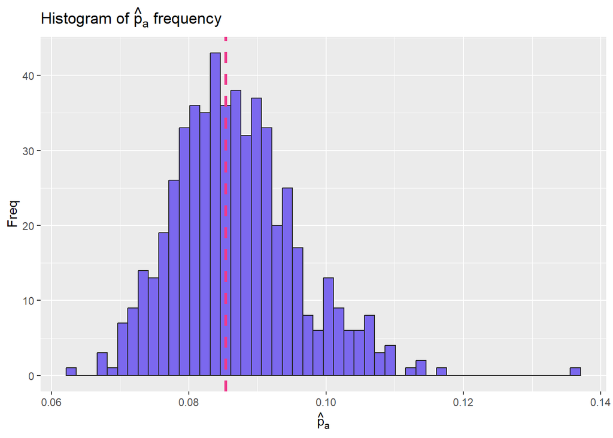

```r
# TRUE freq of 'a'
p_a <- letter_counts %>% filter(letter == "a") %>% pull(p)

# for each bio, compute estimated freq of 'a'
compute_pa <- function(text) {
  chars <- str_split(tolower(text), "")[[1]]           # split into characters
  letters_only <- keep(chars, is_letter)               # keep only a-z, is_letter my function from q7
  n_letters <- length(letters_only)                    # total letters
  n_a <- sum(letters_only == "a")                      # how many 'a'

  p_hat <- if (n_letters > 0) n_a / n_letters else NA  # avoid divide by 0
  list(p_hat = p_hat, length = n_letters)
}

# apply to all bios from bio vector, filter missing or empty bios
pa_df <- map_dfr(bio, compute_pa) %>%
  filter(!is.na(p_hat), length > 0)

# assuming each letter is an i.i.d. Bernoulli trial where success = letter is 'a'
# then Var(p_hat) = p_a * (1 - p_a) / n comes from the variance of the sample mean of Bernoulli variables
pa_df <- pa_df %>%
  mutate(
    abs_err = abs(p_hat - p_a),                     # compute absolute error
    std_dev = sqrt(p_a * (1 - p_a) / length)        # and theoretical std dev
  )


# Histogram of estimators
ggplot(pa_df, aes(x = p_hat)) +
  geom_histogram(bins = 50, fill = "mediumslateblue", color = "gray15") +
  geom_vline(xintercept = p_a, color = "violetred2", linetype = "dashed", linewidth = 1.2) +
  labs(
    title = expression("Histogram of " * hat(p)[a] * " frequency"),
    x = expression(hat(p)[a]),
    y = "Freq"
  )
```

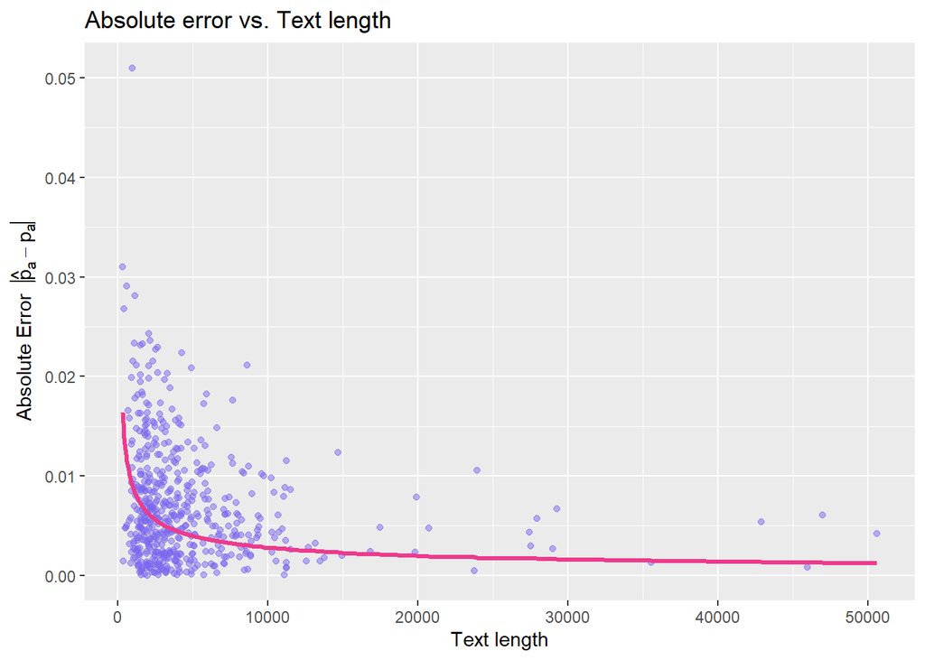

```r
# Scatterplot: error vs length
ggplot(pa_df, aes(x = length, y = abs_err)) +
  geom_point(alpha = 0.5, color = "mediumslateblue") +
  geom_line(aes(y = std_dev), color = "violetred2", linewidth = 1.2) +
  labs(
    title = "Absolute error vs. Text length",
    x = "Text length",
    y = expression("Absolute Error  "*abs(hat(p)[a] - p[a]))
  )
```

The first plot displays the histogram of these estimators with 50 bins. The dashed vertical line corresponds to the global frequency $p_a$, computed earlier. The distribution of $\hat{p}_a(s)$ appears approximately symmetric and concentrated around the true value, indicating that the global estimate is consistent across different biographies.

The second plot presents the absolute estimation error $|\hat{p}_a(s) - p_a|$ as a function of the text length $l(s)$ for each scientist. The overlaid line shows the theoretical standard deviation $\sqrt{p_a (1 - p_a) / l(s)}$, derived under the simplifying assumption that each letter in the text is drawn independently (i.i.d.) with success probability $p_a$. As expected, the error decreases with text length, confirming that longer texts yield more accurate estimates. This illustrates the law of large numbers and shows that even under the i.i.d. model, we obtain a useful approximation for the variability of letter frequency estimators.

### Simulate 4-letter words with an i.i.d. model

Letters are sampled independently from the empirical alphabet distribution; we check what fraction of 10 000 words are in a dictionary. [words_alpha](https://raw.githubusercontent.com/dwyl/english-words/master/words_alpha.txt).

To assess how well a simple generative model based on empirical letter frequencies replicates actual English words, we simulated 10,000 words of length 4. Each word was formed by independently sampling four letters from the empirical letter distribution $\{p_i\}_{i=1}^{26}$, previously estimated from the aggregated biographies text.

```r
set.seed(123)

# Extract the vector of frequencies, computed in q7, in the alphabet order
freq_vec <- letter_counts %>%
  arrange(match(letter, letters)) %>%  # reorder rows in the alphabet order
  pull(p)

# Generate 10000 random 4 letter words by sampling letters independently
# according to their empirical frequencies freq_vec
simulated_words <- replicate(10000,
  paste0(sample(letters, 4, replace = TRUE, prob = freq_vec), collapse = ""))


words_alpha_txt <- readLines("https://raw.githubusercontent.com/dwyl/english-words/master/words_alpha.txt") %>%
  tolower() %>%
  .[nchar(.) == 4]   # keep only words of length 4

# Check which simulated words exist in the dictionary
real_words <- simulated_words %in% words_alpha_txt

# Compute the fraction of simulated words that are real English words
fraction <- mean(real_words)
count_real <- sum(real_words)

cat("Out of 10000 simulated (i.i.d model) 4-letter words,", count_real,
    "are actual English words (", round(fraction * 100, 3), "%).\n", sep = " ")
```

```
## Out of 10000 simulated (i.i.d model) 4-letter words, 668 are actual English words ( 6.68 %).
```

We then checked how many of these generated 4-letter strings correspond to actual English words using a standard dictionary (`words_alpha.txt`). Out of the 10,000 generated words, 668 were found in the dictionary, yielding a match rate of approximately $6.68\%$. This proportion may vary slightly across simulations due to randomness, but typically remains in the range of $6\%$–$7\%$.

This relatively low proportion indicates that modeling word formation by sampling letters independently does not sufficiently capture the structure of real English words. It demonstrates that valid English words are governed by additional syntactic and phonological constraints that are not reflected in a simple i.i.d. model.

### Simulate 4-letter words with a bigram model

Letters are sampled with conditional bigram probabilities, greatly increasing the share of valid English words.

Using the bigram model, we generated 10,000 four-letter words where the first letter was sampled independently from the empirical letter frequencies, and each subsequent letter was sampled conditionally based on the preceding letter using the transition probabilities $p_{ij}$. These conditional probabilities were derived from the relative bigram frequencies observed in the biographies.

```r
set.seed(123)

# Build matrix P - conditional probability of letter j to appear after letter i from the bigram_table
row_tot <- rowSums(bigram_table)            # total bigram count for each letter (vector with 26 enters)
P <- sweep(
  x      = bigram_table,
  MARGIN = 1,              # operate across rows (1 = rows, 2 = columns)
  STATS  = row_tot,
  FUN    = "/"             # divide each cell by its row total
)                          # each row now sums to 1 so, we have probability distribution

#  helper func, that generate one 4-letter word from the first
word_gen <- function() {
  c1 <- sample(letters, 1, prob = freq_vec)                  # first letter chosen by frequencies from q10
  c2 <- sample(letters, 1, prob = P[match(c1, letters), ])   # second letter conditional on c1
  c3 <- sample(letters, 1, prob = P[match(c2, letters), ])
  c4 <- sample(letters, 1, prob = P[match(c3, letters), ])

  paste0(c1, c2, c3, c4)                                     # return the four-letter string
}

simulated_words_1 <- replicate(10000, word_gen())              # simulate 10 000 words

# Check which simulated words is real and calculate proportion in 10000 simulated
real_words_1 <- simulated_words_1 %in% words_alpha_txt
fraction_1 <- mean(real_words_1)
count_real_1 <- sum(real_words_1)

cat("Out of 10000 simulated (bigram model) 4-letter words,",  count_real_1,
  "are actual English words (", round(fraction_1 * 100, 3), "%).\n", sep = " ")
```

```
## Out of 10000 simulated (bigram model) 4-letter words, 2244 are actual English words ( 22.44 %).
```

```r
cat(
  "i.i.d. model hit-rate:", round(fraction * 100, 3), "% —",
  count_real, "real words out of 10000",
  "\nbigram model hit-rate:", round(fraction_1 * 100, 3), "% —",
  count_real_1, "real words out of 10000\n"
)
```

```
## i.i.d. model hit-rate: 6.68 % — 668 real words out of 10000
## bigram model hit-rate: 22.44 % — 2244 real words out of 10000
```

Compared to the i.i.d. model, which achieved a match rate of approximately $6\%$–$7\%$, the bigram model produces significantly more realistic English-like words with match rate $22\%$–$24\%$.

### Probability of repeating a word in two draws (Monte Carlo)

A monkey picks two words *with replacement* from the biography vocabulary, using empirical word frequencies.  
We run a Monte-Carlo simulation (10 000 pairs) and also compute the exact probability to see how often the second word matches the first.

In this simulation, we estimated the probability that a randomly typed two-word sentence contains the same word twice. Each word was sampled independently *with replacement* from the full collection of words extracted from the biographies, with sampling probabilities proportional to the words’ empirical frequencies.

```r
set.seed(123)

# helper func, returns a tibble with word frequencies and probabilities.
get_word_probs <- function(wrd) {
  wrd %>%
    count(word, sort = TRUE) %>%
    mutate(prob = n / sum(n))
}

word_probs <- get_word_probs(clean_words)

# simulate 2 vectors of 10000 words  (with replacement)
words1 <- sample(word_probs$word, 10000, replace = TRUE, prob = word_probs$prob)
words2 <- sample(word_probs$word, 10000, replace = TRUE, prob = word_probs$prob)

# calculate probabilities
empirical_prob <- mean(words1 == words2)
theoretical_prob <- sum(word_probs$prob^2)

cat("Out of 10000 pairs,", sum(words1 == words2), "are identical\n")
```

```
## Out of 10000 pairs, 7 are identical
```

```r
cat("Empirical probability:", empirical_prob, "\n")
```

```
## Empirical probability: 0.0007
```

```r
cat("Theoretical probability:", theoretical_prob, "\n")
```

```
## Theoretical probability: 0.0007099181
```

Also probability can be calculated exactly. Since both words are chosen independently with the same probability distribution, the exact chance that the same word appears twice is:

$$P(\text{same word}) = \sum_{i=1}^{n} p_i^2$$

where $p_i$ is the probability of choosing word $i$. This formula gives the total probability that both random draws give the same word. In our case, this exact value was around $0.00071$.

### Probability of forming three Curie-family names

The monkey shuffles eight specific words — **Maria, Skłodowska, Curie, Pierre, Curie, Irène, Joliot, Curie** (three “Curie”) — *without replacement*.  
We estimate how often the resulting 8-word sentence contains all three scientist names *MariaSkłodowskaCurie*, *PierreCurie*, and *IrèneJoliotCurie* (order free, spaces ignored).  
An exact count is theoretically possible but combinatorially complicated, so we rely on simulation.

We ran a simulation with 50,000 random sentences made by shuffling the eight given words. We checked how many of these sentences contained all three full scientist names: `MariaSkłodowskaCurie`, `PierreCurie`, and `IrèneJoliotCurie` (without spaces and in that exact order for each name).

```r
set.seed(123)
words_q13 <- c("Maria", "Skłodowska", "Curie", "Pierre", "Curie", "Irène", "Joliot", "Curie")
names_target <- c("MariaSkłodowskaCurie", "PierreCurie", "IrèneJoliotCurie")

# helper func, check if all target names are present in the sentence
contains_three_fullnames <- function(wrds) {
  sentence <- paste0(wrds, collapse = "")
  all(str_detect(sentence, names_target))
}

# Generate 50000 random permutations of words_q13
gen_sentences <- replicate(50000, sample(words_q13), simplify = FALSE)

# Count how many of 50,000  contain all 3 full names
# map_lgl() applies the check helper function to each sentence
num_of_hits <- sum(map_lgl(gen_sentences, contains_three_fullnames))

# Estimate probability
estimated_prob_q13 <- num_of_hits / 50000

# Output result
cat("Number of hits:", num_of_hits, "\n")
```

```
## Number of hits: 46
```

```r
cat("Estimated probability:", estimated_prob_q13, "\n")
```

```
## Estimated probability: 0.00092
```

In total, 46 out of 50,000 sentences had all three names, so the estimated probability is:

$$\hat{P} = \frac{46}{50{,}000} = 0.00092$$

It is possible to calculate the exact probability, but it’s difficult because the word `Curie` appears three times, and each of the three full names requires its own `Curie`. The total number of unique permutations of the eight words is $\frac{8!}{3!} = 6720$. To compute the exact probability, we would need to count how many of these 6720 arrangements contain all three full names, without overlaps or repeated use of the same `Curie`. This is quite complex combinatorially.

Note that this result may vary slightly from simulation to simulation, but it tends to stay around the same small probability.

### Monkey typing probability of “Rosalind Franklin”

```r
# Target name, all lowercase and no spaces
target_q14 <- "rosalindfranklin"
letters_vec_q14 <- str_split(target_q14, "")[[1]]
n_letters_q14 <- length(letters_vec_q14)

# Uniform model, each letter has probability 1/26
uniform_prob <- (1 / 26)^(n_letters_q14)
log_uniform_prob <- -n_letters_q14 * log(26)

# Empirical model, based on probability letter_counts from q7
empirical_probs_q14 <- letter_counts %>%
  arrange(match(letter, letters)) %>%
  pull(p)

names(empirical_probs_q14) <- letters

# Get probability of each letter in target under empirical model
letter_probs_q14 <- empirical_probs_q14[letters_vec_q14]

# Compute log-probability
log_prob_q14 <- sum(log(letter_probs_q14))
empirical_prob_q14 <- exp(log_prob_q14)

cat("Uniform model probability:  ", uniform_prob,
    "\nEmpirical model probability:", empirical_prob_q14,
    "\nLog-probability under uniform model:  ", log_uniform_prob,
    "\nLog-probability under empirical model:", log_prob_q14, "\n")
```

```
## Uniform model probability:   0.00000000000000000000002293118
## Empirical model probability: 0.000000000000000000003742051
## Log-probability under uniform model:   -52.12954
## Log-probability under empirical model: -47.03465
```

To estimate the probability that a monkey randomly types the exact string “rosalindfranklin”, we used two models. In the **uniform model**, each letter has equal probability $\frac{1}{26}$, so the total probability is extremely small, around $2.29 \times 10^{-23}$.

To make the comparison clearer, we used log-probabilities. The log-probability in the uniform case was approximately -52.13, while in the empirical case it was around -47.03. The log scale helps visualize differences in extremely small probabilities, which would otherwise be hard to compare directly.